# Lab Assignment One: Exploring Table or Text Data

Group

Renjie(Sebastian) Lu (48030051)

Liwei Li (47708015)

Wu Zhongling(47777045)

Tianyi Zheng(47777123)

# 1. Business Understanding

## Introduction to the Car Sales dataset

Craigslist is the one of the world's largest collection of used vehicles for sale, yet it's very difficult to collect all of them in the same place. Craigslist collects the used vehicles all over the world including Asia and Africa. It's hard to put all those used vehicles data together because huge data amount and some regional restriction such as currency float and privacy policy. This data only collected the used vehicles information in the United States where Craigslist shares the biggest market over the world. This data is scraped every few months, it contains most all relevant information that Craigslist provides on car sales including columns like price, condition, manufacturer, latitude/longitude, and 16 other categories.

## The purpose of the dataset

Again, those used vehicles information was collected from Craigslist. They have all relevant information about the used cars they gave for sales including sales price. The Craigslist get those used cars information once they buy the car from previous owner or car reports or they just check the vin number of that used car they will have all the relevant information about that car. Since they have collected the information about the used car they bought, they will store that information into their database and put it online with the price for customers. Customer can access the information from anywhere instead of going to the retail store for price and information they need. Another reason they store those information besides for sales would be management level. Craigslist share the large proportion of the used cars market, managing those assets (aka used cars) effectively is also what they need to concern. With those used car information they stored, they can easily check those inventories.

## Prediction task for your data

Through processing the data, we really want to know what are the key factors influence the sales price of the used cars on Craigslist. In short, our goal is giving the prediction of the price range of a car based certain attributes of the car information as accurate as possible.

## Who else interested in the result?

Every potential used car consumer should be interesed on this model, since it could save you massive money once the prediction is accurate.

For internatioal students who newly enter U.S., they really want to buy an ideal car with desired price. They must interested on this analyise report.

## How well would your prediction algorithm need to perform to be considered useful to these third parties?

The model should give a result of what impact factors of price are? and how they will influent the sell price? The price range of the prediction should be as accurate as possible.

Moreover, most international students have the consideration of the resalability of their cars, since they won't stay U.S. for a dacade. Therefore, we could give a prediction of resalability.

# 2. Data understanding

```python
#attribute pandas & numpy to csv.
import pandas as pd
import numpy as np

print('Pandas:', pd.__version__)
print('Numpy:',np.__version__)

#import raw data, named as 'cars'
cars = pd.read_csv('https://raw.githubusercontent.com/sebastian0303/CS7324/master/CS%207324%20LAB%20ONE%20.csv')

#TEST READING
cars.head()
```

```
Pandas: 0.24.2
Numpy: 1.16.4
```

|  | url | city | price | year | manufacturer | make | condition | cylinders | fuel | odometer | ... | size | type | paint_color | lat | long | county_fips | county_name | state_code | state_name | weather |
| --- | --- | --- | --- | --- | --- | --- | --- | --- | --- | --- | --- | --- | --- | --- | --- | --- | --- | --- | --- | --- | --- |
| 0 | https://marshall.craigslist.org/cto/d/2010-dod... | marshall | 11900 | 2010.0 | dodge | challenger se | good | 6 cylinders | gas | 43600.0 | ... | NaN | coupe | red | 43.4775 | -96.7041 | 46083.0 | Lincoln | SD | South Dakota | 38.0 |
| 1 | https://marshall.craigslist.org/cto/d/fleetwoo... | marshall | 1515 | 1999.0 | NaN | fleetwood | NaN | NaN | gas | NaN | ... | NaN | NaN | NaN | 44.7612 | -96.6907 | 46039.0 | Deuel | SD | South Dakota | 38.0 |
| 2 | https://marshall.craigslist.org/cto/d/2008-for... | marshall | 17550 | 2008.0 | ford | f-150 | NaN | NaN | gas | NaN | ... | NaN | NaN | NaN | 44.1415 | -103.2052 | 46093.0 | Meade | SD | South Dakota | 38.0 |
| 3 | https://marshall.craigslist.org/cto/d/ford-tau... | marshall | 2800 | 2004.0 | ford | taurus | good | 6 cylinders | gas | 168591.0 | ... | full-size | sedan | grey | 43.2845 | -95.5930 | 19143.0 | Osceola | IA | Iowa | 47.0 |
| 4 | https://marshall.craigslist.org/cto/d/2001-gra... | marshall | 400 | 2001.0 | NaN | 2001 Grand Prix | NaN | NaN | gas | 217000.0 | ... | NaN | NaN | NaN | 43.0261 | -94.4064 | 19109.0 | Kossuth | IA | Iowa | 47.0 |

5 rows × 24 columns

```python
print(cars.info())
```

```
<class 'pandas.core.frame.DataFrame'>
RangeIndex: 119784 entries, 0 to 119783
Data columns (total 24 columns):
url             119784 non-null object
city            119784 non-null object
price           119784 non-null int64
year            119227 non-null float64
manufacturer    109597 non-null object
make            114653 non-null object
condition       71411 non-null object
cylinders       67705 non-null object
fuel            118829 non-null object
odometer        78193 non-null float64
title_status    119245 non-null object
transmission    118854 non-null object
vin             38329 non-null object
drive           70971 non-null object
size            39691 non-null object
type            67592 non-null object
paint_color     67150 non-null object
lat             119784 non-null float64
long            119784 non-null float64
county_fips     99688 non-null float64
county_name     99688 non-null object
state_code      99688 non-null object
state_name      119784 non-null object
weather         99611 non-null float64
dtypes: float64(6), int64(1), object(17)
memory usage: 21.9+ MB
None
```

```python
# check the duplicate instances
dup = cars.duplicated()

print("There are {} duplicate instance".format(len(cars[dup])))
```

```
There are 0 duplicate instance
```

Before we step into data quality step, we would like to check the duplicated here since we have ‘vin’ number of the car which is like a unique id of car.

We are happy to see there is no duplicated here. We are good to next step.

```python
# capitalize columns name to avoid colliding reserved keywords
cars.columns = map(str.capitalize, cars.columns)
print(cars.info())
```

```
<class 'pandas.core.frame.DataFrame'>
RangeIndex: 119784 entries, 0 to 119783
Data columns (total 24 columns):
Url             119784 non-null object
City            119784 non-null object
Price           119784 non-null int64
Year            119227 non-null float64
Manufacturer    109597 non-null object
Make            114653 non-null object
Condition       71411 non-null object
Cylinders       67705 non-null object
Fuel            118829 non-null object
Odometer        78193 non-null float64
Title_status    119245 non-null object
Transmission    118854 non-null object
Vin             38329 non-null object
Drive           70971 non-null object
Size            39691 non-null object
Type            67592 non-null object
Paint_color     67150 non-null object
Lat             119784 non-null float64
Long            119784 non-null float64
County_fips     99688 non-null float64
County_name     99688 non-null object
State_code      99688 non-null object
State_name      119784 non-null object
Weather         99611 non-null float64
dtypes: float64(6), int64(1), object(17)
memory usage: 21.9+ MB
None
```

```python
import matplotlib
import matplotlib.pyplot as plt
import warnings
warnings.simplefilter('ignore', DeprecationWarning)
%matplotlib inline

import missingno as mn

mn.matrix(cars)
```

[output not shown]

```python
# clean the dataset

for col in ['Url','Vin', 'Lat', 'Long', 'County_fips', 'County_name', 'State_code',  'City', 'Weather', 'Make']:
    if col in cars:
        del cars[col]

cars_imputing = cars.dropna(subset=['Year','Type','Condition','Manufacturer','Cylinders','Drive','Paint_color','Size'])

print(cars_imputing.info())
```

```
<class 'pandas.core.frame.DataFrame'>
Int64Index: 28737 entries, 3 to 119782
Data columns (total 14 columns):
Price           28737 non-null int64
Year            28737 non-null float64
Manufacturer    28737 non-null object
Condition       28737 non-null object
Cylinders       28737 non-null object
Fuel            28737 non-null object
Odometer        23838 non-null float64
Title_status    28737 non-null object
Transmission    28733 non-null object
Drive           28737 non-null object
Size            28737 non-null object
Type            28737 non-null object
Paint_color     28737 non-null object
State_name      28737 non-null object
dtypes: float64(2), int64(1), object(11)
memory usage: 3.3+ MB
None
```

The reason why we delete those attributes:

Url: Link to the used car list on Craigslist. It makes no sense for analysis or prediction.

Vin: unique ID of each car. It makes no sense for analysis or prediction.

Lat & long: City coordinates in map. We have the city name which is the same and easier understanding in visualization.

Couny_name, county_fips: already have city and state information.

State_code: same as state name.

City: We dont need city name since we have satae

Weather: Weather is the temperature of the locat place in Nov. and Oct..

Make: We more care about Manfacturer than Make. Make is the model of the car under manfacturer.

Among the attributes with the missing value, we eliminate rows with missing value in those attributes because they have large number of missing values and it is hard to impute a value for them (Most of them are object, if we imputed a most frequent value, due to large number of missing values, it may influence the data quality and outcome). In other words, we believe imputation (only for those attributes) will impact on our data quality. Another reason we believe elimination is better that imputation is that we will still have large number of data after elimination. Our dataset will be good after elimination. (Only 'year' which with few missing values, it is OK to drop the rows with miss value)

```python
cars_imputing.shape
```

```
(28737, 14)
```

After elimination, we still have 14 attributs and 28,737 rows

```python
#information of dataset we interested

cars_imputing.describe()
```

|  | Price | Year | Odometer |
| --- | --- | --- | --- |
| count | 2.873700e+04 | 28737.000000 | 2.383800e+04 |
| mean | 1.288393e+05 | 2005.143195 | 1.203700e+05 |
| std | 1.105906e+07 | 11.627291 | 1.136011e+05 |
| min | 1.000000e+00 | 1918.000000 | 0.000000e+00 |
| 25% | 3.750000e+03 | 2002.000000 | 6.440000e+04 |
| 50% | 7.988000e+03 | 2007.000000 | 1.135715e+05 |
| 75% | 1.600000e+04 | 2012.000000 | 1.600000e+05 |
| max | 1.234568e+09 | 2019.000000 | 3.990000e+06 |

```python
# check the duplicate instances

#we have checked when we still have 'vin', we check it agian to see what happened
dup = cars.duplicated()

print("There are {} duplicate instance".format(len(cars[dup])))
```

```
There are 14206 duplicate instance
```

We observed 14206 duplicated instances. However, this is allowed. Without ‘vin’ number, there could exist cars with same information.

```python
#check missing value

mn.matrix(cars.sort_values(by=["odometer","drive","condition","cylinders"]))
```

[output not shown]

We still have missing values, this time, we will imputed it (odometer).

```python
# group attributes relevant to odometer
cars_grouped = cars_imputing.groupby(by=['Year','Condition','Type'])

cars_imputed = cars_grouped.transform(lambda grp: grp.fillna(grp.median()))

col_deleted = list( set(cars_imputing.columns) - set(cars_imputed.columns))
cars_imputed[col_deleted] = cars_imputing[col_deleted]

print(cars_imputed.info())
```

```
<class 'pandas.core.frame.DataFrame'>
Int64Index: 28737 entries, 3 to 119782
Data columns (total 14 columns):
Price           28737 non-null int64
Odometer        28190 non-null float64
Type            28737 non-null object
State_name      28737 non-null object
Title_status    28737 non-null object
Drive           28737 non-null object
Manufacturer    28737 non-null object
Cylinders       28737 non-null object
Year            28737 non-null float64
Transmission    28733 non-null object
Condition       28737 non-null object
Paint_color     28737 non-null object
Size            28737 non-null object
Fuel            28737 non-null object
dtypes: float64(2), int64(1), object(11)
memory usage: 3.3+ MB
None
```

```python
cars_imputed.dropna(inplace=True)

print(cars_imputed.info())
```

```
<class 'pandas.core.frame.DataFrame'>
Int64Index: 28186 entries, 3 to 119782
Data columns (total 14 columns):
Price           28186 non-null int64
Odometer        28186 non-null float64
Type            28186 non-null object
State_name      28186 non-null object
Title_status    28186 non-null object
Drive           28186 non-null object
Manufacturer    28186 non-null object
Cylinders       28186 non-null object
Year            28186 non-null float64
Transmission    28186 non-null object
Condition       28186 non-null object
Paint_color     28186 non-null object
Size            28186 non-null object
Fuel            28186 non-null object
dtypes: float64(2), int64(1), object(11)
memory usage: 3.2+ MB
None
```

```python
# convert year to integer
cars_imputed = cars_imputed.astype({'Year': 'int64'})
# quantify cylinders
cars_imputed.Cylinders.replace(to_replace=['6 cylinders','5 cylinders','4 cylinders','other','10 cylinders','12 cylinders','3 cylinders','8 cylinders'],
                               value=[6,5,4,0,10,12,3,8],
                               inplace=True)

cars_imputed.Condition.replace(to_replace=['salvage', 'fair', 'good', 'excellent', 'like new', 'new'],
                               value=[1,2,3,4,5,6],
                               inplace=True)

cars_imputed.Size.replace(to_replace=['sub-compact', 'compact', 'mid-size', 'full-size'],
                               value=[1,2,3,4],
                               inplace=True)

cars_imputed.Title_status.replace(to_replace=['rebuilt', 'salvage', 'lien', 'parts only', 'missing'],
                               value='not clean',
                               inplace=True)




cars_imputed.info()
```

```
<class 'pandas.core.frame.DataFrame'>
Int64Index: 28186 entries, 3 to 119782
Data columns (total 14 columns):
Price           28186 non-null int64
Odometer        28186 non-null float64
Type            28186 non-null object
State_name      28186 non-null object
Title_status    28186 non-null object
Drive           28186 non-null object
Manufacturer    28186 non-null object
Cylinders       28186 non-null int64
Year            28186 non-null int64
Transmission    28186 non-null object
Condition       28186 non-null int64
Paint_color     28186 non-null object
Size            28186 non-null int64
Fuel            28186 non-null object
dtypes: float64(1), int64(5), object(8)
memory usage: 3.2+ MB
```

```python
# rearrange the columns
cars_imputed = cars_imputed [['Manufacturer','Year','Type','Size',
                          'Drive','Cylinders','Paint_color','Fuel',
                          'Transmission','Condition','Odometer',
                          'Title_status','Price','State_name']]

print (cars_imputed.info())

cars_imputed.head()
```

```
<class 'pandas.core.frame.DataFrame'>
Int64Index: 28186 entries, 3 to 119782
Data columns (total 14 columns):
Manufacturer    28186 non-null object
Year            28186 non-null int64
Type            28186 non-null object
Size            28186 non-null int64
Drive           28186 non-null object
Cylinders       28186 non-null int64
Paint_color     28186 non-null object
Fuel            28186 non-null object
Transmission    28186 non-null object
Condition       28186 non-null int64
Odometer        28186 non-null float64
Title_status    28186 non-null object
Price           28186 non-null int64
State_name      28186 non-null object
dtypes: float64(1), int64(5), object(8)
memory usage: 3.2+ MB
None
```

|  | Manufacturer | Year | Type | Size | Drive | Cylinders | Paint_color | Fuel | Transmission | Condition | Odometer | Title_status | Price | State_name |
| --- | --- | --- | --- | --- | --- | --- | --- | --- | --- | --- | --- | --- | --- | --- |
| 3 | ford | 2004 | sedan | 4 | fwd | 6 | grey | gas | automatic | 3 | 168591.0 | clean | 2800 | Iowa |
| 6 | jeep | 2015 | SUV | 1 | 4wd | 4 | grey | gas | automatic | 5 | 39500.0 | not clean | 12500 | South Dakota |
| 10 | Chervrolet | 2006 | van | 4 | rwd | 6 | white | gas | automatic | 3 | 138000.0 | clean | 4000 | FAILED |
| 11 | Chervrolet | 2002 | truck | 4 | 4wd | 8 | white | diesel | automatic | 4 | 350000.0 | clean | 13000 | FAILED |
| 12 | hyundai | 2016 | sedan | 4 | fwd | 4 | white | gas | other | 5 | 44814.0 | clean | 21695 | FAILED |

```python
df_describe = pd.DataFrame()

pd.set_option('max_colwidth', 200)
df_describe['Attribute'] = cars_imputed.columns
df_describe['Description'] = ['Manufacturer of vehicle', 'Year of vehicle made',
                          'Vehicle type','Size of Vehicle','Drive of vehicle',
                          'Number of cylinders of vehicle', 'Color of vehicle',
                          'Fuel taken by vehicle', 'Transmission of vehicle',
                          'Condition of vehicle', 'Miles vehicle has been driven(unit in mile)','Title status of vehicle',
                          'Price of vehicle(unit in dollar)','Location of vehicle stored']
df_describe['Scales'] = ['norminal'] +['ratio'] + ['norminal']+['Ordinal']+['norminal'] +['Ordinal']+['norminal']*3+ ['Ordinal']+['interval']+['ordianl']+['interval']+['norminal']
df_describe['Discrete\Continuous'] = ['discrete'] + ['continuous'] + ['discrete']*8 +['continuous'] + ['discrete']+['continuous'] + ['discrete']

df_describe['Range'] = [repr(set(cars_imputed.Manufacturer))] + ['1923-2019']+[repr(set(cars_imputed.Type))]+['sub-compact=1, compact=2, mid-size=3, full-size=4'] + \
                    [repr(set(cars_imputed.Drive))]+ ['6 cylinders=6, 5 cylinders=5, 4 cylinders=4, other=0, 10 cylinders=10, 12 cylinders=12, 3 cylinders=3, 8 cylinders=8']+\
                    [repr(set(cars_imputed.Paint_color))] + [repr(set(cars_imputed.Fuel))]+[repr(set(cars_imputed.Transmission))]+\
                    ['salvage=1, fair=2, good=3, excellent=4, like new=5, new=6'] + ['0-300,500']+[repr(set(cars_imputed.Title_status))]+['1-34,299']+\
                    [repr(set(cars_imputed.State_name))]

df_describe
```

[output not shown]

We don't have missing values now.

# 3. Data Visualization

```python
import matplotlib
import matplotlib.pyplot as plt
import warnings
warnings.simplefilter('ignore', DeprecationWarning)
%matplotlib inline

print('Matplotlib:', matplotlib. __version__)
```

```
Matplotlib: 3.1.0
```

```python
import seaborn as sns
cmap = sns.diverging_palette(220, 10, as_cmap=True) # one of the many color mappings

print('Seaborn:', sns. __version__)
```

```
Seaborn: 0.9.0
```

```python
plt.style.use('ggplot')
```

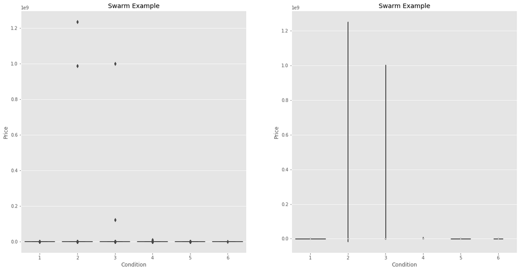

```python
plt.subplots(figsize=(20, 10))

plt.subplot(1,2,1)
sns.boxplot(x="Condition", y="Price",data=cars_imputed)
plt.title('Swarm Example')

plt.subplot(1,2,2)
sns.violinplot(x="Condition", y="Price",data=cars_imputed)
plt.title('Swarm Example')

plt.show()
```

Observed many unusual high price value, which increased the scale and make the main plot not visible and those outliers make no sense to our project. We need to move those outlier before we move on.

```python
#https://towardsdatascience.com/ways-to-detect-and-remove-the-outliers-404d16608dba
# We use IQR to define the outlier in dataset
Q1 = cars_imputed.quantile(0.25)
Q3 = cars_imputed.quantile(0.75)
IQR = Q3 - Q1

noise_odometer = (cars_imputed.Odometer < (Q1.Odometer - 1.5 * IQR.Odometer)) | (cars_imputed.Odometer > (Q3.Odometer + 1.5 * IQR.Odometer))
noise_price = (cars_imputed.Price < (Q1.Price - 1.5 * IQR.Price)) | (cars_imputed.Price > (Q3.Price + 1.5 * IQR.Price))

cars_imputed = cars_imputed[~(noise_odometer | noise_price)]
# cars_imputed = cars.imputed[~((cars_imputed < (Q1 - 1.5 * IQR)) | (cars_im))]

print(cars_imputed.info())
# print(noise_price)
# print(noise_odometer | noise_price)

cars_imputed.head()
```

```
<class 'pandas.core.frame.DataFrame'>
Int64Index: 26290 entries, 3 to 119782
Data columns (total 14 columns):
Manufacturer    26290 non-null object
Year            26290 non-null int64
Type            26290 non-null object
Size            26290 non-null int64
Drive           26290 non-null object
Cylinders       26290 non-null int64
Paint_color     26290 non-null object
Fuel            26290 non-null object
Transmission    26290 non-null object
Condition       26290 non-null int64
Odometer        26290 non-null float64
Title_status    26290 non-null object
Price           26290 non-null int64
State_name      26290 non-null object
dtypes: float64(1), int64(5), object(8)
memory usage: 3.0+ MB
None
```

|  | Manufacturer | Year | Type | Size | Drive | Cylinders | Paint_color | Fuel | Transmission | Condition | Odometer | Title_status | Price | State_name |
| --- | --- | --- | --- | --- | --- | --- | --- | --- | --- | --- | --- | --- | --- | --- |
| 3 | ford | 2004 | sedan | 4 | fwd | 6 | grey | gas | automatic | 3 | 168591.0 | clean | 2800 | Iowa |
| 6 | jeep | 2015 | SUV | 1 | 4wd | 4 | grey | gas | automatic | 5 | 39500.0 | not clean | 12500 | South Dakota |
| 10 | Chervrolet | 2006 | van | 4 | rwd | 6 | white | gas | automatic | 3 | 138000.0 | clean | 4000 | FAILED |
| 12 | hyundai | 2016 | sedan | 4 | fwd | 4 | white | gas | other | 5 | 44814.0 | clean | 21695 | FAILED |
| 13 | Chervrolet | 2011 | coupe | 4 | rwd | 6 | green | gas | manual | 5 | 101000.0 | clean | 18000 | FAILED |

# 3.1 Data Exploration

## 3.1.1 Price Distribution

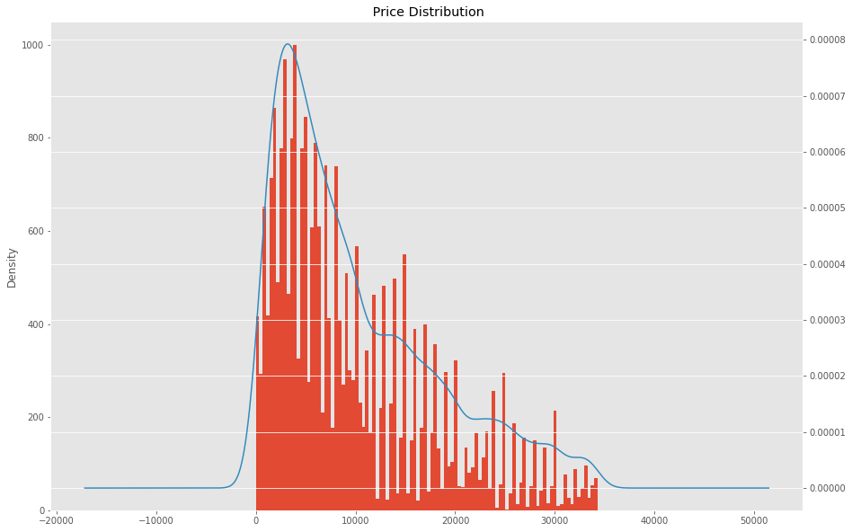

```python
plt.style.use('ggplot')

# checking the price distribution
fig = plt.figure(figsize=(15,10))
cars_imputed.Price.plot.hist(bins=100)
cars_imputed.Price.plot.kde(secondary_y=True)
plt.title(' Price Distribution')
plt.show()
```

The plot shows the price distribution in the used car market. From the frequency and density in this plot, we conclude that the most of used cars price are less than $10000.

## 3.1.2 Distribution of Manufacturer

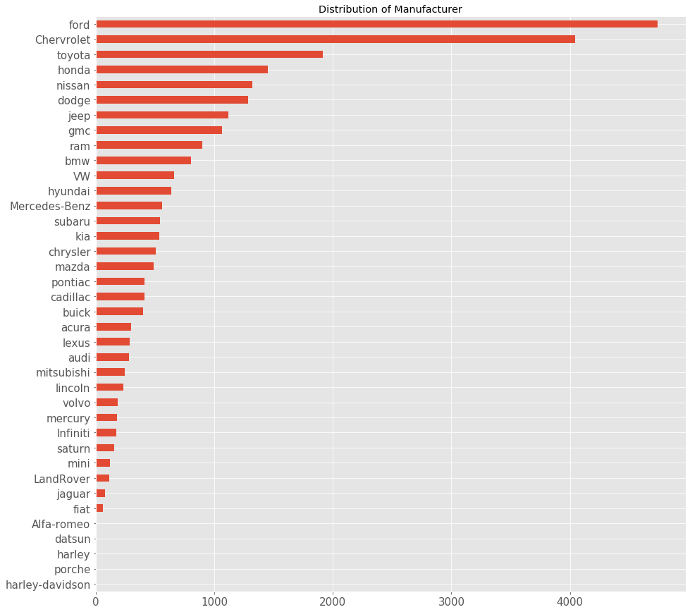

```python
plt.figure(figsize=(15,15))
cars_imputed['Manufacturer'].value_counts(ascending=True).plot(kind='barh',fontsize=15)
plt.title('Distribution of Manufacturer')
```

Ford has largest share in US used car market, follows by Chervrolet and Toyta. Those are the top3 manafacturers in US used car market with very high inventory than other manfacturers.

## 3.1.3 Distribution of Year

```python
#Year data summary
cars_imputed.Year.describe()
```

```
count    26290.000000
mean      2005.422024
std          9.943414
min       1923.000000
25%       2003.000000
50%       2007.000000
75%       2012.000000
max       2019.000000
Name: Year, dtype: float64
```

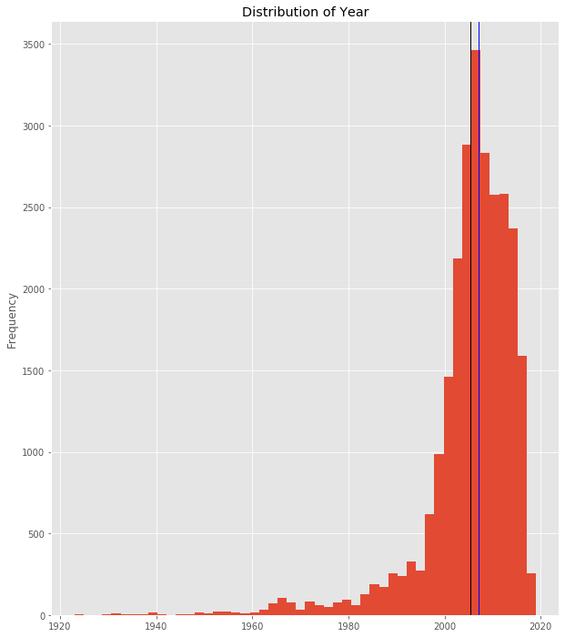

```python
#Describe the distribution of year
plt.figure(figsize=(10,12))
cars_imputed.Year.plot.hist(bins=50)
plt.axvline(cars_imputed.Year.mean(), color='black', linewidth=1)
plt.axvline(cars_imputed.Year.median(), color='blue', linewidth=1)
plt.title('Distribution of Year')
plt.show()
```

The balck bar indicates the sample mean and blue line. The plot shows the peaks numbers of used cars are in 2005-2006 year range. From the plot, we could know that around 2005-2006 yeared car have strong market.

## 3.1.4 Distribution of Odometer

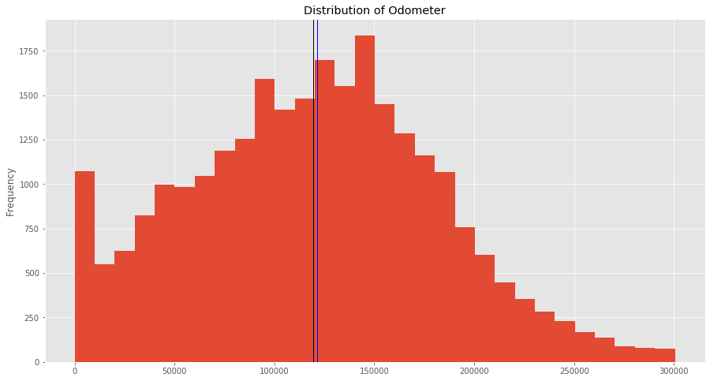

```python
#distribution of the odometer
fig = plt.figure(figsize=(15,8))
cars_imputed.Odometer.plot.hist(bins=30)
plt.axvline(cars_imputed.Odometer.mean(), color='black', linewidth=1)
plt.axvline(cars_imputed.Odometer.median(), color='blue', linewidth=1)
plt.title('Distribution of Odometer')
plt.show()
```

The historygram to show the blueline(median) and blaclline(mean) nearley same. However, the peek numbers of the used cars are around 150000.

## 3.1.5 Common Type Used Cars

```
Fuel             diesel  electric   gas  hybrid  other
Drive Cylinders
4wd   0               7         0    13       0      0
      3               0         0     5       0      0
      4              25         0  1819      10      1
      5               0         0    90       0      0
      6             331         0  3961       7      3
      8             691         0  4093       1      8
      10              1         0   107       0      0
      12              1         0     0       0      0
fwd   0               2        11     9       0      1
      3               0         0    24       2      0
      4              98         5  5377     147      6
      5               0         0   144       0      0
      6              13         0  3111       5      2
      8              13         0   326       1      0
      10              1         0     3       0      0
      12              1         0     0       0      0
rwd   0               4         0    35       0      0
      3               0         0     5       0      0
      4              12         1   610       1      0
      5              16         0    19       0      0
      6             109         1  1826       1      4
      8             171         0  2911       1      3
      10              0         0    71       0      0
      12              1         0    12       0      0
```

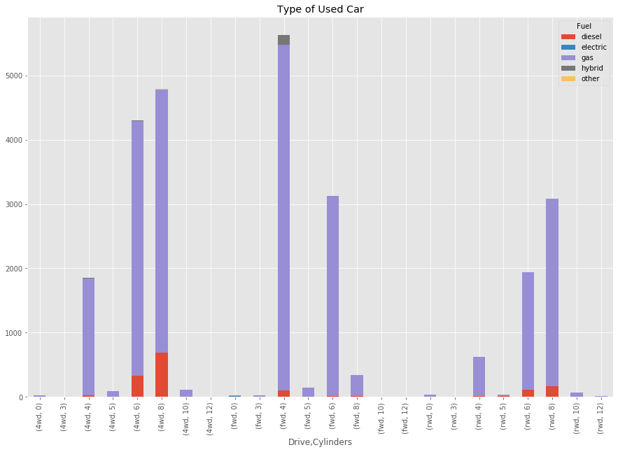

```python
car_type = pd.crosstab([cars_imputed['Drive'],
                        cars_imputed['Cylinders']], # categories to cross tabulate
                       cars_imputed['Fuel']) # how to group
print(car_type)
car_type.plot(kind='bar', stacked=True, figsize=(15, 10))
plt.title('Type of Used Car')
plt.show()
```

The most common used car in US market is forward drive, 4 cylinders, gas fuel car. Noticed hybrid and electric energy cars which is very popular in recent years have low inventory in used car market. Most of them are new cars so it is hard to find new energy viehicles in used car market.

## 3.1.6 Prefered Used Car Type

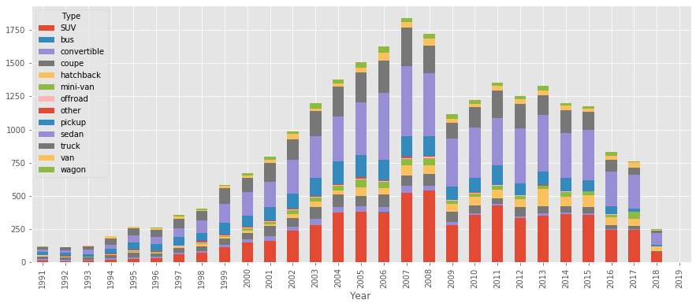

```python
cars_imputed1 = cars_imputed[cars_imputed.Year>1990]
categories = pd.crosstab(cars_imputed1.Year,cars_imputed1.Type)
categories.plot(kind='bar', stacked=True, figsize=(15,6))
plt.show()
```

## 3.1.7 Year vs. Price

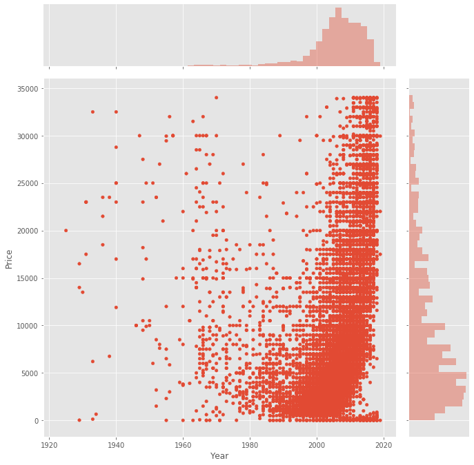

```python
#Draw scatterplot: Year vs Price
sns.jointplot(x="Year",y="Price",data=cars_imputed, kind="scatter", sizes=(20,0))
plt.gcf().set_size_inches((10, 10))
plt.show()
```

1.From the distribution of scattter plot shows that most ammounts of used cars are after 1980 year in the market.

2.The price correlated with year in 2 year range. After 1980, ther are modern used car which has positive correlation with price. However, before 1980, the price and year are negative correlation. The reason is the old historical vehicles gain value as it older with good condition and rare production.

```python
cars_imputed['range'] = pd.cut(cars_imputed['Year'],[1920, 1940,1960,1980,2000,2020] )
```

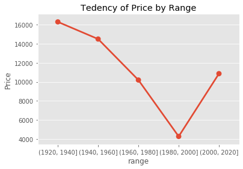

```python
#draw line distribution with mean price value in each year range
plt.title('Tedency of Price by Range')
sns.pointplot(x='range', y='Price', data=cars_imputed.groupby('range', as_index=False).mean())
```

we choose the price sample mean in each year range. The point plot shows the price changes tend in whole used car market based on the year of the car.

## 3.1.8 Odmeter vs. Price

```python
cars_imputed['Mileage'] = pd.cut(cars_imputed['Odometer'],[0, 50000, 100000,150000,200000,250000,300500] )
```

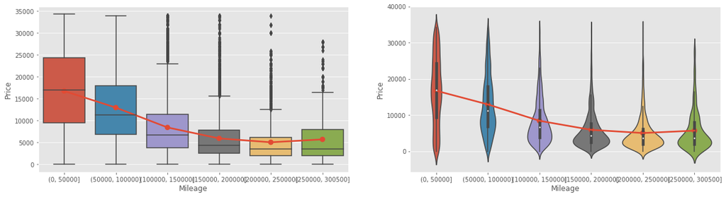

```python
#Boxplot of mean price value in each category of the odometer
plt.figure(figsize=(20,5))
plt.subplot(1,2,1)
ax =sns.boxplot(x="Mileage", y="Price",  data=cars_imputed)
sns.pointplot(x='Mileage', y='Price', data=cars_imputed.groupby('Mileage', as_index=False).mean(), ax=ax)

#Violinplot of mean price value in each category of the odometer
plt.subplot(1,2,2)
az=sns.violinplot(x="Mileage", y="Price",  data=cars_imputed)
sns.pointplot(x='Mileage', y='Price', data=cars_imputed.groupby('Mileage', as_index=False).mean(), ax=az)
plt.show()
```

## 3.1.9 Price Distribution in Each Condition & Odometer Distribution in Each Condition

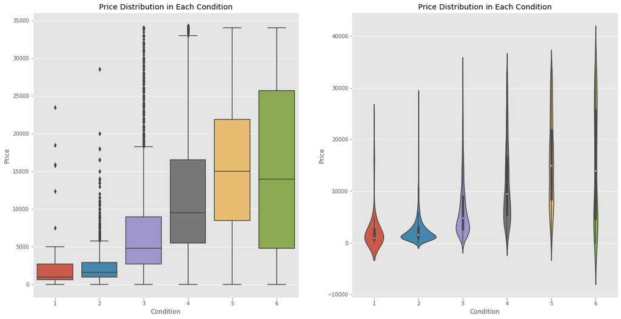

```python
plt.subplots(figsize=(20, 10))

plt.subplot(1,2,1)
sns.boxplot(x="Condition", y="Price",data=cars_imputed)
plt.title('Price Distribution in Each Condition')

plt.subplot(1,2,2)
sns.violinplot(x="Condition", y="Price",data=cars_imputed)
plt.title('Price Distribution in Each Condition')

plt.show()

# notes: salvage=1, fair=2, good=3, excellent=4, like new=5, new=6
```

Some tricky points here. “Likely new” vehicles has higher median price than “new” ones. That’s interesting because we usually think “new” vehicles have highest average price. What we suggest here is to avoid choose “Likely new” vehicles. Another point is that “Likely new” vehicles and “new” vehicles price distribute evenly especially “new” vehicles. “Likely new” vehicles and “new” vehicles are good for customers who are not price sensitive.

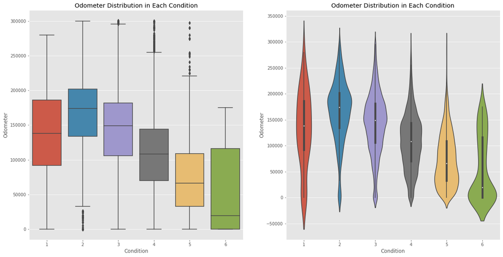

```python
plt.subplots(figsize=(20, 10))

plt.subplot(1,2,1)
sns.boxplot(x="Condition", y="Odometer",data=cars_imputed)
plt.title('Odometer Distribution in Each Condition')

plt.subplot(1,2,2)
sns.violinplot(x="Condition", y="Odometer",data=cars_imputed)
plt.title('Odometer Distribution in Each Condition')
```

# 3.2 Data Relationship

## 3.2.1 Correaltion Matrix

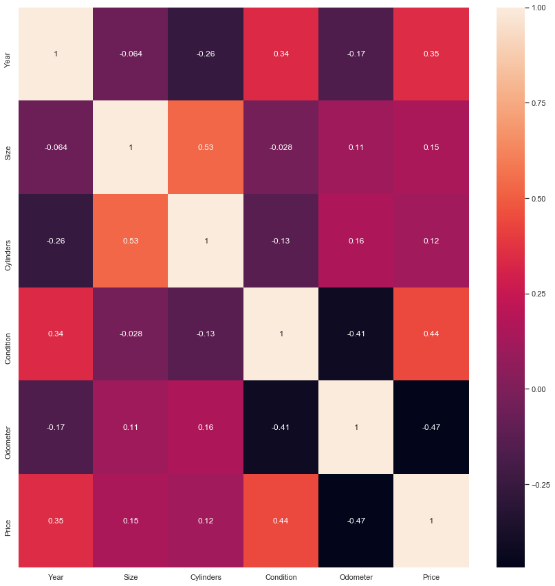

```python
cmap = sns.set(style="darkgrid") # one of the many styles to plot using

f, ax = plt.subplots(figsize=(12, 12))
sns.heatmap(cars_imputed.corr(), cmap=cmap, annot=True)

f.tight_layout()
```

## 3.2.2 Title Status

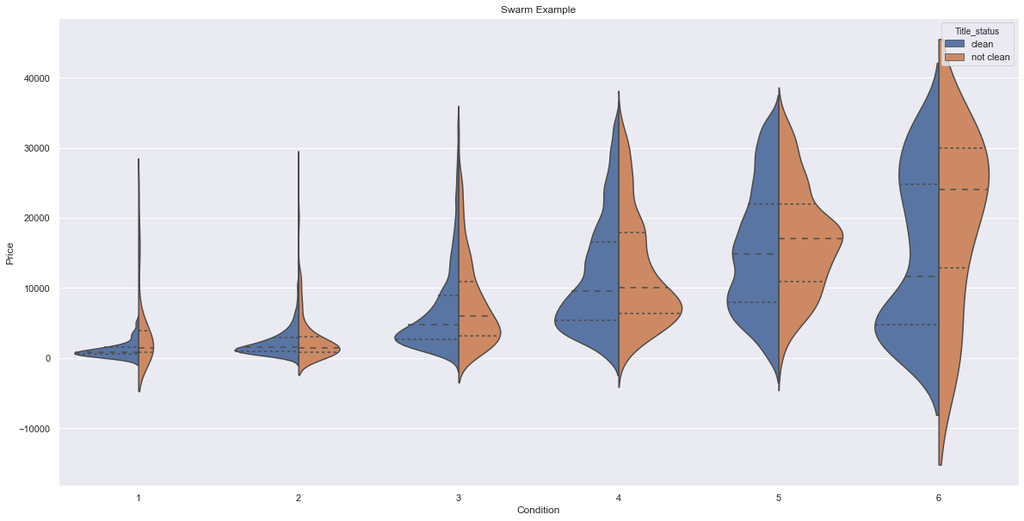

```python
plt.subplots(figsize=(20, 10))
sns.violinplot(x="Condition", y="Price", hue="Title_status", data=cars_imputed,
               split=True, inner="quart")
plt.title('Swarm Example')
```

In first five conditions (salvage=1, fair=2, good=3, excellent=4, like new=5), clean title vehicles and not clean title vehicles have similar price distribution. In ‘new’ condition, price distribution of clean title and not clean tile are extremely different. In ‘new’ condition, not clean title vehicles has much higher median price than clean title vehicles. Most clean title new vehicles with price of $5,000 and $25,000 and most not clean title new vehicles with price of $27,000.

If customers are sensitive to title status, please be more careful when choosing ‘new’ vehicles.

# 4. Dimensionality Reduction

t-SNE is a nice tool to visualize and understand high-dimensional data. It is a dimensionality reduction methods which reduce dimensionality of data to 2 or 3 dimensions very like PCA. The main difference between these two methods is the way they put similarity together. The first step of t-SNE is to t- convert distances between data in the original space to probabilities. We compute conditional probabilities which will be used to generate joint probabilities. It then pick object with similar high probability and then it together.

```python
import sklearn
from sklearn.decomposition import PCA #Though we did not use
from sklearn.manifold import TSNE

#select the subset I want
df_Y = cars_imputed.Price
df_X = cars_imputed[['Odometer','Year','Condition','Cylinders','Size']]
#Price is the target

#implement t-sne
X_tsne = TSNE(learning_rate=300,n_components=2).fit_transform(df_X)

#we set higher learning_rate than ususal due to huge dataset
```

We set ‘Price’ as potential target. This is what we want to predict and analyses in this project. We set the learning rate a little bit higher than usual because the huge dataset we have.

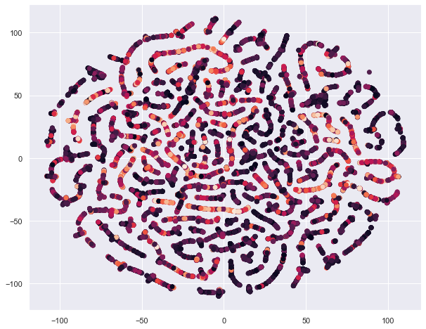

```python
plt.figure(figsize=(10, 8))
plt.scatter(X_tsne[:,0], X_tsne[:,1], c=df_Y)
```

We reduce dimension from 5 to 2. However, no obvious cluster can be observed from scatter plot. In each cluster, there are many different color close together tightly. This might because the range of price be too long and cloud not provide very clear information.

```python
# We would like to try Odometer as target to see change
df_Y2 = cars_imputed.Odometer
df_X2 = cars_imputed[['Price','Year','Condition','Cylinders','Size']]
#Odometer is the target


#implement t-sne
X2_tsne = TSNE(learning_rate=300,n_components=2).fit_transform(df_X2)
```

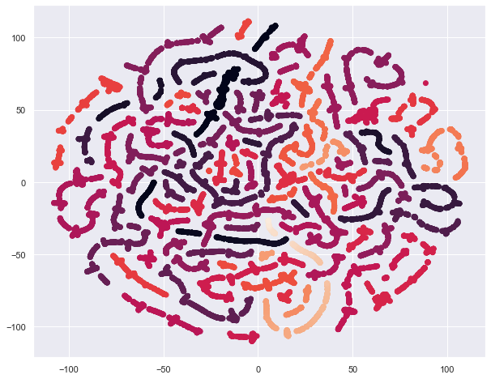

```python
plt.figure(figsize=(10, 8))
plt.scatter(X_tsne[:,0], X_tsne[:,1], c=df_Y2)
```

Reference: http://alexanderfabisch.github.io/t-sne-in-scikit-learn.html https://nbviewer.jupyter.org/urls/gist.githubusercontent.com/AlexanderFabisch/1a0c648de22eff4a2a3e/raw/59d5bc5ed8f8bfd9ff1f7faa749d1b095aa97d5a/t-SNE.ipynb https://distill.pub/2016/misread-tsne/